# Creating images with R

With a little bit of magick

who am I?

```css
/* Original CSS */
h1 {
    font-family: Arial, sans-serif
    color: #007bff;
    font-size: 28px;

body {
    background-color: #fff;
}

p {
    font-size: 16px;
    line-height: 1.6;
}
```

## Project requirements

To fulfill the project requirements related to GitHub, I have meticulously managed my project repository and utilized GitHub Pages for hosting. My GitHub repository contains all project files, including HTML, CSS, Rmd, and image files. I have regularly committed changes, utilized branching for feature development, and merged branches upon completion. The repository also includes a README.md file providing project overview and setup instructions. Additionally, I have configured GitHub Pages to host my project website.Here are the links to my GitHub repository: [https://github.com/Freyaljy/cats_coffee/commit/3f872aca9c160b6ee1918e8f8d64e963c9e695aa].

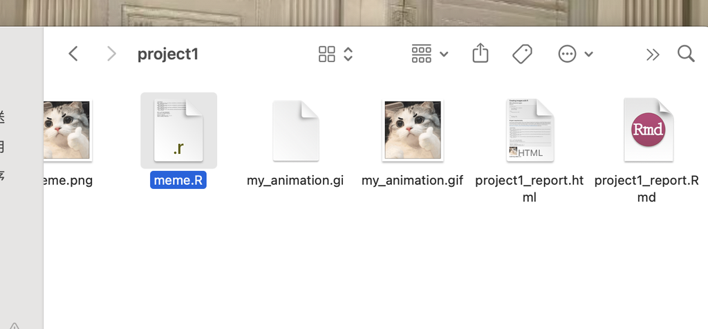

```r
screenshot <- image_read("/Users/liujingyi/Desktop/stats 220/stats220(1)/project1/screenshot.png")
screenshot
```

## My meme

```r
library(magick)
#create my meme
meme <- image_read("https://img.36krcdn.com/20220128/v2_b75552449b724cc584cfd7ca6c476221_img_000?x-oss-process=image/format,jpg/interlace,1")%>%
  image_scale(170)
meme1 <- image_read("https://img.36krcdn.com/20220128/v2_0d2f182c015f4beea49026c58cedec63_img_000?x-oss-process=image/format,jpg/interlace,1")%>%
  image_scale(170)
meme2 <- image_read("https://img.36krcdn.com/20220128/v2_725c8f3a7fe24484940fae8306d861e4_img_000?x-oss-process=image/format,jpg/interlace,1")%>%
  image_scale(170)
meme3 <- image_read("https://imgs.qiubiaoqing.com/qiubiaoqing/imgs/63feb112ad63aMFS.gif")%>%
  image_scale(170)


meme5 <- c(meme,meme1,meme2,meme3)
Final_image <- image_append(meme5)
image_write(Final_image, "my_animation.gi")
```

[figure not shown]

```r
#Creating a animation
meme_gif <- image_animate(meme5, fps = 1)
image_write(meme_gif,"my_animation.gif")
```

## Learning reflection

From Module 1’s exploration of Creating HTML by combining modern technologies, a key takeaway was the interconnected nature of web development tools. The integration of {magick} for image manipulation and advanced CSS techniques demonstrated the symbiotic relationship between different technologies, enriching the visual and functional aspects of HTML pages. Looking ahead, my curiosity is piqued in exploring dynamic data technologies, particularly delving into JavaScript for interactive elements. The prospect of utilizing APIs and databases to enhance real-time updating of web content is intriguing. I am eager to comprehend the seamless integration of dynamic data sources into web development, as it opens avenues for creating more responsive and user-centric applications.